Football is a game requiring a combination of strength, athleticism, and skills, but also a game of strategy and decision making, especially from the quarterback and coach. It’s a game of chess but with 250lb players as pieces. As like any other game, there are clear distinctions between good and bad teams (players). Each year we can see which teams are suited to make a championship run and which teams are competing for the top draft pick. What we are interested in today is to be able to predict the outcome of any NFL game using good or bad qualities and statistics that define a team. There are several methods to do this and so we will go through 3 of them.

## Negative Binomial Model

The first model we will examine is the negative binomial model. The model is based on the number of points scored/allowed by each team. Teams that have scored more points in the past have a greater probability of scoring more points in the future. First we’ll import NFL game data from the current (2018-2019) season. This data was found at [www.pro-football-reference.com](https://www.pro-football-reference.com/).

| Week | Day | Date | Time | Winner | V6 | Loser | V8 | PtsW | PtsL | YdsW | TOW | YdsL | TOL |
| --- | --- | --- | --- | --- | --- | --- | --- | --- | --- | --- | --- | --- | --- |
| 1 | Thu | September 6 | 8:20PM | Philadelphia Eagles |  | Atlanta Falcons | boxscore | 18 | 12 | 232 | 2 | 299 | 1 |
| 1 | Sun | September 9 | 1:00PM | Pittsburgh Steelers | @ | Cleveland Browns | boxscore | 21 | 21 | 472 | 6 | 327 | 1 |
| 1 | Sun | September 9 | 1:00PM | Cincinnati Bengals | @ | Indianapolis Colts | boxscore | 34 | 23 | 330 | 2 | 380 | 2 |
| 1 | Sun | September 9 | 1:00PM | Miami Dolphins |  | Tennessee Titans | boxscore | 27 | 20 | 342 | 2 | 336 | 3 |
| 1 | Sun | September 9 | 1:00PM | Tampa Bay Buccaneers | @ | New Orleans Saints | boxscore | 48 | 40 | 529 | 0 | 475 | 2 |
| 1 | Sun | September 9 | 1:00PM | Baltimore Ravens |  | Buffalo Bills | boxscore | 47 | 3 | 369 | 1 | 153 | 2 |

Now since we are interested in the number of points scored by each team, let’s take a look at the distribution of points scored. We will look at the number of points scored in each game by both the home and away team.

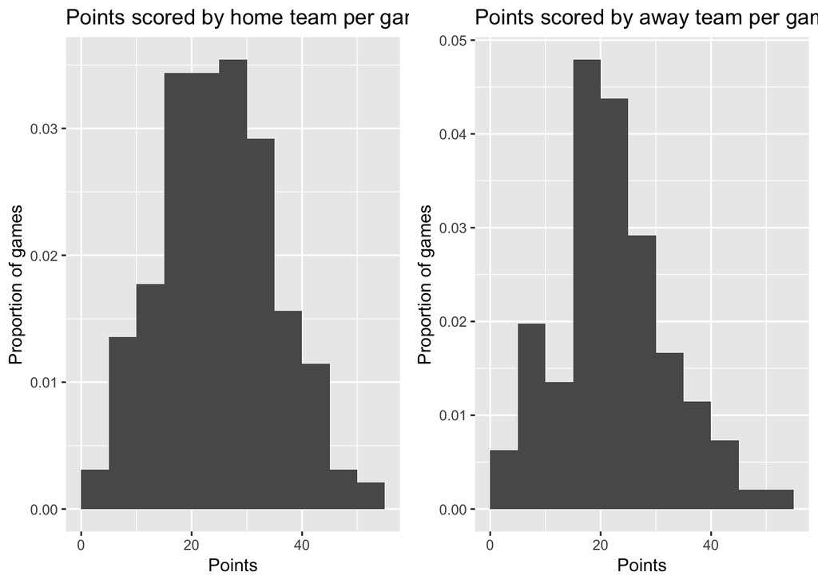

```r
kable(describe(reg1$Home_Pts)) %>%
  kable_styling(bootstrap_options = c("striped", "condensed"))
```

|  | vars | n | mean | sd | median | trimmed | mad | min | max | range | skew | kurtosis | se |
| --- | --- | --- | --- | --- | --- | --- | --- | --- | --- | --- | --- | --- | --- |
| X1 | 1 | 192 | 25.15625 | 10.4183 | 24 | 24.95455 | 10.3782 | 0 | 54 | 54 | 0.1746325 | -0.2244053 | 0.7518758 |

#### Fitting the distribution

Looking at the histogram and the parameters, we can see that both the home and away points seem to share the same characteristics as a negative binomial distribution, hence our model. Let’s fit the distribution:

```r
fit_home <- fitdistr(reg1$Home_Pts, "negative binomial")
fit_away <- fitdistr(reg1$Away_Pts, "negative binomial")
```

And now, let’s overlay the fit on our previous histogram and see if the negative binomial distribution is actually a good fit.

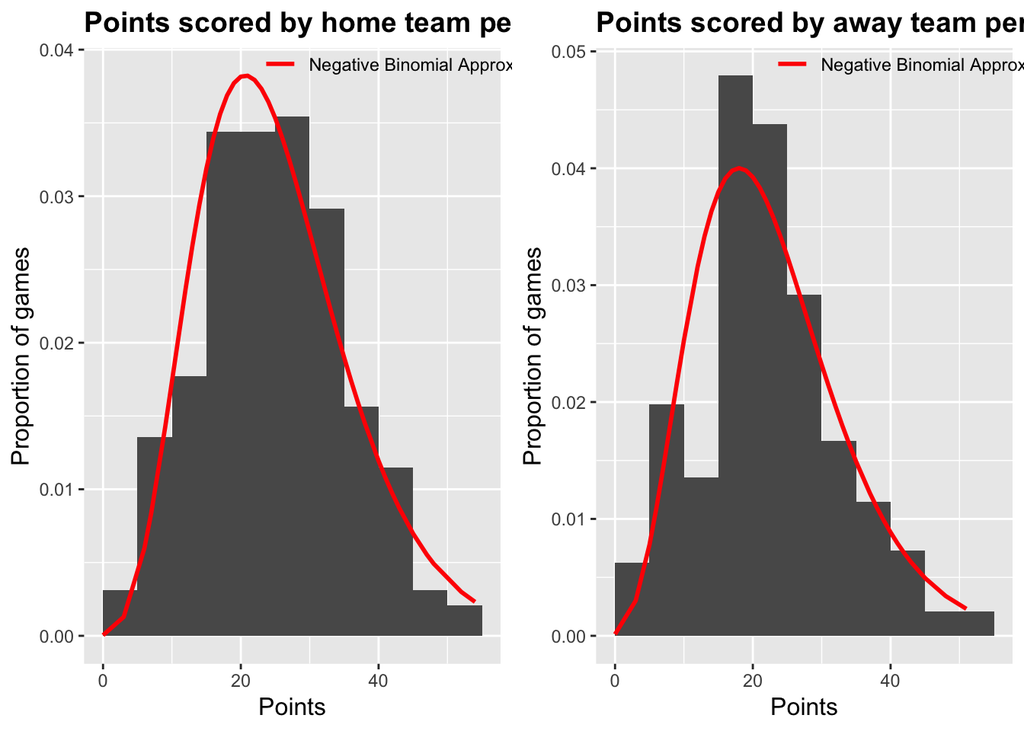

Alright, so at this point, we should be pretty convinced that the number of points scored per game by a team can be approximated with a negative binomial data. Now we can move on to our next step.

### Getting Teams Data

To test our model, we will need to simulate a match between two teams and predict the probability of winning for either team. In our case we will use the upcoming match of the Dallas Cowboys v. Philadelphia Eagles.

First we’ll grab the Cowboys regular season stats.

```r
cowboys <- reg_season[Winner == "Dallas Cowboys" | Loser == "Dallas Cowboys", ]
```

Since we are only interested in the points scored, that is the only stat we will extract from out dataset.

```r
cowboys_pts <- cowboys[Winner == "Dallas Cowboys", "PtsW"] %>%
  append(cowboys[Loser == "Dallas Cowboys", "PtsL"]) %>%
  unlist()
```

Similarly, we are also interested in how points are allowed by the team. This stat here measures how good the defense is of the team.

```r
cowboys_ptsa <- cowboys[!Loser == "Dallas Cowboys", "PtsL"] %>%
  append(cowboys[!Winner == "Dallas Cowboys", "PtsW"]) %>%
  unlist()
```

We also need to obtain the same data for the opposing team, which would be the Phildelphia Eagles.

```r
eagles <- reg_season[Winner == "Philadelphia Eagles" | Loser == "Philadelphia Eagles", ]
```

```r
eagles_pts <- eagles[Winner == "Philadelphia Eagles", "PtsW"] %>%
  append(eagles[Loser == "Philadelphia Eagles", "PtsL"]) %>%
  unlist()
```

```r
eagles_ptsa <- eagles[!Loser == "Philadelphia Eagles", "PtsL"] %>%
  append(eagles[!Winner == "Philadelphia Eagles", "PtsW"]) %>%
  unlist()
```

We now have 4 vectors of points scored and points allowed for both the Cowboys and the Eagles. For visualizing purposes, let’s take a look at what the data we will be using looks like:

|  | PtsW1 | PtsW2 | PtsW3 | PtsW4 | PtsW5 | PtsW6 |
| --- | --- | --- | --- | --- | --- | --- |
| **Dallas Cowboys** |  |  |  |  |  |  |
| Point Scored | 20 | 26 | 40 | 27 | 22 | 31 |
| Points Allowed | 13 | 24 | 7 | 20 | 19 | 23 |
| **Philadelphia Eagles** |  |  |  |  |  |  |
| Points Scored | 18 | 20 | 34 | 24 | 25 | 28 |
| Points Allowed | 12 | 16 | 13 | 18 | 22 | 13 |

### Building the model and simulating the game

Now that we have our data prepared, we are ready to build the model. First, we want to fit the distribution for the points scored and points allowed for both and grab the parameter estimates from the fits.

```r
inputs <- cbind(cowboys_pts, cowboys_ptsa, eagles_pts, eagles_ptsa)

for(i in 1:4){
  fit <- fitdistr(inputs[,i][inputs[,i] > 0], "negative binomial")
  params[i,] <- c(fit$estimate[1], fit$estimate[2])
}
```

Great, we now have our parameter estimates stored in a matrix. Next we need to come up with a good way to simulate the game. The function rnbinom() can provide one single sample for each of our inputs (points scored and points allowed) for both teams, meaning we can get a random approximation of points scored and points allowed by each team for one simulation. That’s a step in the right direction, however, using that method poses 2 problems: 1. We now have 4 approximations (points scored and allowed for each team) that we must combine into 2 2. One single sample is not very reliable and most likely not a good represenation of how either team will fare - we need more samples

Let’s address the latter first. The solution to this problem is very simple. We increase the number of simulations. For this case, we will use 100,000 simulations. My statistics professor always told me that the larger the sample size, the more reliable your averages will be. One might even say, the N’s justify the means…thank you everybody, I’ll see myself out now. But in all seriousness:

```r
niterations = 100000
j = 1
while(j <= niterations){
    cowboys_off = rnbinom(1, size = params[1,1], mu = params[1,2])
    cowboys_def = rnbinom(1, size = params[2,1], mu = params[2,2])
    eagles_off = rnbinom(1, size = params[3,1], mu = params[3,2])
    eagles_def = rnbinom(1, size = params[4,1], mu = params[4,2])

    ...
}
```

Ok so we’ve fixed out small sample size problem but now we a solution to our first problem. Why we need to combine our 4 approximations into 2? That’s because we are using those point approximations to predict the final scores for each team. The scoreboard will only show 2 different points, the home team’s score and the opposing team’s score. So what we do need to combine? The approximated points scored by the Cowboys (offense) and the approximated points allowed by the Eagles (defense) and vice versa. The number of points scored and the number of points allowed is the same statistic, it’s just a matter of looking at it from a offensive or defenseive perspective. Since those inputs are essentially measuring the thing, we’ll just take the average of the 2.

```r
cowboys_score = round(mean(c(cowboys_off, eagles_def)))
eagles_score = round(mean(c(eagles_off, cowboys_def)))
```

We now have all of the information we need to finalize our model and generate winning probabilities for both teams. What we want to do is count how many times one team beats the other and the percentage of that from all the simulations is the winning percentage for that team. If the Cowboys beat the Eagles in 59 out of 100 simulations, we will say that the Cowboys have a 59% chance of beating the Eagles. Putting everything together from previous steps, we get:

```r
niterations = 100000
j = 1
while(j <= niterations){
    # Record a single sample for points score and allowed by both teams
    cowboys_off = rnbinom(1, size = params[1,1], mu = params[1,2])
    cowboys_def = rnbinom(1, size = params[2,1], mu = params[2,2])
    eagles_off = rnbinom(1, size = params[3,1], mu = params[3,2])
    eagles_def = rnbinom(1, size = params[4,1], mu = params[4,2])

    # Get the approximated scores by averaging the points score/allowed
    cowboys_score = round(mean(c(cowboys_off, eagles_def)))
    eagles_score = round(mean(c(eagles_off, cowboys_def)))

    # Throw out ties
    if(cowboys_score == eagles_score) {next}

    # Store final scores in a vector
    cowboys_game_score[j] <- cowboys_score
    eagles_game_score[j] <- eagles_score

    # Check who wins and store that information into a vector
    cowboys_wins[j] = ifelse(cowboys_score > eagles_score, 1, 0)
    eagles_wins[j] = ifelse(eagles_score > cowboys_score, 1, 0)

    # Next simulation
    j <- j + 1
}
```

To get the approximated winning percentages for both teams, we need just simply sum up the number of wins by each team in the simulations and take it as a percentage of all the simulations.

```r
cowboys_win_pct <- sum(cowboys_win)/niterations * 100
eagles_win_pct <- sum(eagles_win)/niterations * 100
```

| Dallas.Cowboys | Philadelphia.Eagles |
| --- | --- |
| 56.2 % | 43.8 % |

## Logistic Regression Model

The second model we are interested in is the logistic regression model. This is quite different than the negative binomial model we just used. Rather than approximating the number of points scored by each team, the logistic regression model will attempt to predict an outcome of a single binary variable (in our case win or lose) by using a number of predictors. The model follows the equation:

$\ l = \beta_0 + \beta_1x + \beta_2x + ... + \ e$

where $\ l$ is the log-odds and each of the $\beta$’s are the predictors. So how do we know which predictors we want to add to our model? Let’s take a look at our data again.

| Week | Day | Date | Time | Winner | V6 | Loser | V8 | PtsW | PtsL | YdsW | TOW | YdsL | TOL |
| --- | --- | --- | --- | --- | --- | --- | --- | --- | --- | --- | --- | --- | --- |
| 1 | Thu | September 6 | 8:20PM | Philadelphia Eagles |  | Atlanta Falcons | boxscore | 18 | 12 | 232 | 2 | 299 | 1 |
| 1 | Sun | September 9 | 1:00PM | Pittsburgh Steelers | @ | Cleveland Browns | boxscore | 21 | 21 | 472 | 6 | 327 | 1 |
| 1 | Sun | September 9 | 1:00PM | Cincinnati Bengals | @ | Indianapolis Colts | boxscore | 34 | 23 | 330 | 2 | 380 | 2 |
| 1 | Sun | September 9 | 1:00PM | Miami Dolphins |  | Tennessee Titans | boxscore | 27 | 20 | 342 | 2 | 336 | 3 |
| 1 | Sun | September 9 | 1:00PM | Tampa Bay Buccaneers | @ | New Orleans Saints | boxscore | 48 | 40 | 529 | 0 | 475 | 2 |
| 1 | Sun | September 9 | 1:00PM | Baltimore Ravens |  | Buffalo Bills | boxscore | 47 | 3 | 369 | 1 | 153 | 2 |

There isn’t a sure-fire way to select predictors that will be significant, rather, we will rely on intuition. Looking at the data we have, we want to ask which of these variables would make an impact in determining the outcome of the game. Some clear selections would be the the yards gained by the winning and losing teams and also the number of turnovers committed by both teams. Logically, the winning team would have more yards gained and fewer turnovers committed. Another factor that we should consider is whether a team is playing at home. Historically, the home team have won roughly 58% of the games played. One of the most well known home-field advantage is the Denver Broncos. Situated at 5,280 feet above sea-level and located in a city where winter weather conditions can be brutal, this stadium has proven to be troubling for visiting teams and has earned the name “Mile High Stadium”. The Denver Broncos hold a 71.6% win rate when playing at home, which is the highest home winning percentage of all NFL teams. A complete list of how every NFL team fares at home can be found [here](https://www.teamrankings.com/nfl/trends/win_trends/?sc=is_home&range=yearly_all).

### Preparing the Data

For our logistic regression model, we will want to use data from previous years to increase the number of data points we have since every game will be treated as a single individual data point. We did not do this for our negative binomial model because that model focuses on the performance of each team in the current season. Data from previous years may not be indicative of how the team is performing currently and may obscure the data. For our model, we will just be using game data from the last 3 years.

```r
seas2017 <- fread('2017-18.csv')
seas2016 <- fread('2016-17.csv')

# Only use regular season games
reg2017 <- seas2017[1:256,]
reg2016 <- seas2016[1:256,]
```

We did not import in the 2018-2018 season because we already previously did for our previous model. All of this data was also grabbed from [www.pro-football-reference.com](https://www.pro-football-reference.com/).

The first thing we want to do with the data is to create a “Win” variable which takes on a value of 1 for a win and a value of 0 for a loss. We want to do that because that is the variable we will be trying to predict with the logistic regression model. However, you might notice that there is a winner and a loser for every game, it’s just a matter of looking at which team’s perspective. In order to create a win variable without any biases to a particular team, we will split the dataset into 2 random halves and have one half be counted as wins and the other as losses. We do that for each season instead of all seasons combined since we don’t want an uneven number of wins/losses from the different seasons.

```r
ind <- sample(c(TRUE, FALSE), nrow(reg2018), replace=TRUE, prob=c(0.5, 0.5))
reg2018_win <- reg2018[ind, ]
reg2018_loss <- reg2018[!ind, ]

ind <- sample(c(TRUE, FALSE), nrow(reg2017), replace=TRUE, prob=c(0.5, 0.5))
reg2017_win <- reg2017[ind, ]
reg2017_loss <- reg2017[!ind, ]

ind <- sample(c(TRUE, FALSE), nrow(reg2016), replace=TRUE, prob=c(0.5, 0.5))
reg2016_win <- reg2016[ind, ]
reg2016_loss <- reg2016[!ind, ]

reg_df_win <- rbind(reg2018_win, reg2017_win, reg2016_win)
reg_df_loss <- rbind(reg2018_loss, reg2017_loss, reg2016_loss)
```

Next we want to create a binary “Home” variable which indicates if the team is playing on their home field. We will do that for both the “win” dataset and the “loss” dataset.

```r
reg_win <- reg_df_win[, .(Home = ifelse(V6 == '@', 0, 1) %>% as.factor(),
                          Team = Winner,
                          Opponent = Loser,
                          Team_Pts = PtsW,
                          Opponent_Pts = PtsL,
                          Team_Yds = YdsW,
                          Opponent_Yds = YdsL,
                          Team_TO = TOW,
                          Opponent_TO = TOL)]

reg_loss <- reg_df_loss[, .(Home = ifelse(V6 == '@', 0, 1) %>% as.factor(),
                            Team = Loser,
                            Opponent = Winner,
                            Team_Pts = PtsL,
                            Opponent_Pts = PtsW,
                            Team_Yds = YdsL,
                            Opponent_Yds = YdsW,
                            Team_TO = TOL,
                            Opponent_TO = TOW)]

reg_df <- rbind(reg_win, reg_loss)
```

Great, before we move on let’s take a look at what our data looks like now:

| Home | Team | Opponent | Team_Pts | Opponent_Pts | Team_Yds | Opponent_Yds | Team_TO | Opponent_TO |
| --- | --- | --- | --- | --- | --- | --- | --- | --- |
| 1 | Philadelphia Eagles | Atlanta Falcons | 18 | 12 | 232 | 299 | 2 | 1 |
| 0 | Pittsburgh Steelers | Cleveland Browns | 21 | 21 | 472 | 327 | 6 | 1 |
| 0 | Tampa Bay Buccaneers | New Orleans Saints | 48 | 40 | 529 | 475 | 0 | 2 |
| 1 | Baltimore Ravens | Buffalo Bills | 47 | 3 | 369 | 153 | 1 | 2 |
| 0 | Jacksonville Jaguars | New York Giants | 20 | 15 | 305 | 324 | 1 | 2 |
| 1 | New England Patriots | Houston Texans | 27 | 20 | 389 | 325 | 3 | 2 |

The final step in preparing the data is take actually create the binary “Win” variable and take the difference of yards and turnovers between the two teams. We take the difference between those variables because the number of yards (turovers) gained (committed) and allowed are very similar which would likely cause multicollinearity between our predictor variables.

```r
reg_diff <- reg_df[, .(Home,
                       Win = ifelse(Team_Pts > Opponent_Pts, 1, 0) %>% as.factor(),
                       Yds_Diff = Team_Yds - Opponent_Yds,
                       TO_Diff = Team_TO - Opponent_TO)]
```

Let’s take one final look at our data:

| Home | Win | Yds_Diff | TO_Diff |
| --- | --- | --- | --- |
| 1 | 1 | -67 | 1 |
| 0 | 0 | 145 | 5 |
| 0 | 1 | 54 | -2 |
| 1 | 1 | 216 | -1 |
| 0 | 1 | -19 | -1 |
| 1 | 1 | 64 | 1 |

### Building the model

The logistic regression model is actually simple to build. We will be using “Win” as the predicted variable and home-field, yards differential, and turonver differential between the teams as predictors.

```r
logreg <- glm(Win ~ Home + Yds_Diff + TO_Diff, data = reg_diff, family = binomial(link = "logit"))
```

The model is fit but there is a slight problem. In order a to predict the winning percentage for both teams, we must first need to know how many yard each team had during the game and how many turnovers each team committed during the game. To overcome this we can employ a technique we used earlier. If we take a look at the histograms of the yards and turnovers per game, we can see that they can be fit to the normal and exponential distribution respectively.

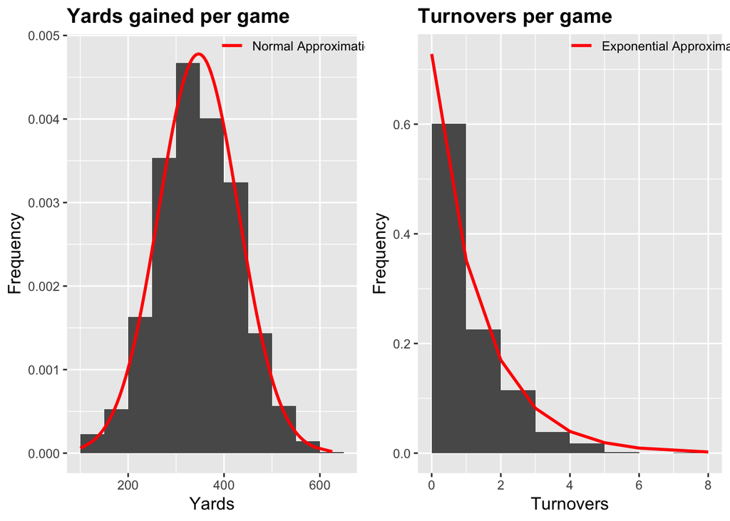

We will simulate the number of yards gained and the number of turnovers committed the same way we did with points in the negative binomial model. Below is the same code we had used previously but just wrapped in a function to fit a normal and exponential distribution.

```r
# Simulate yds
simulate_yds <- function(team_yds) {
  yds_fit <- fitdistr(team_yds, "normal")
  yds <- vector()
  i <- 1
  while(i <= 100000) {
    yds[i] <- rnorm(1, mean = yds_fit$estimate[1], sd = yds_fit$estimate[2])
    i <- i + 1
  }

  e_yds <- sum(yds)/100000
  return(e_yds)
}


# Simulate TOs
simulate_to <- function(team_to) {
  to_fit <- fitdistr(team_to, "exponential")
  to <- vector()
  i <- 1
  while(i <= 100000) {
    to[i] <- rexp(1, rate = to_fit$estimate)
    i <- i + 1
  }

  e_to <- sum(to)/100000
  return(e_to)
}
```

Since we used the Dallas Cowboys and the Phildelphia Eagles, for our previous model, we will continue to use these two teams. We will first now simulate the number of expected yards and turnovers for both teams.

```r
# Get data for Cowboys
cowboys_yds <- reg2018[Winner == "Dallas Cowboys", YdsW] %>%
  append(reg2018[Loser == "Dallas Cowboys", YdsL])
cowboys_to <- reg2018[Winner == "Dallas Cowboys", TOW] %>%
  append(reg2018[Loser == "Dallas Cowboys", TOL])

# Get data for Eagles
eagles_yds <- reg2018[Winner == "Philadelphia Eagles", YdsW] %>%
  append(reg2018[Loser == "Philadelphia Eagles", YdsL])
eagles_to <- reg2018[Winner == "Philadelphia Eagles", TOW] %>%
  append(reg2018[Loser == "Philadelphia Eagles", TOL])

# Simulate yards and TO
e_cowboys_yds <- simulate_yds(cowboys_yds)
e_cowboys_to <- simulate_to(cowboys_to)
e_eagles_yds <- simulate_yds(eagles_yds)
e_eagles_to <- simulate_to(eagles_to)
```

Let’s take a look at the expected number of yards and turnovers for each team.

|  | Expected Yards | Expected TO |
| --- | --- | --- |
| Dallas Cowboys | 331.7560 | 1.001499 |
| Philadelphia Eagles | 361.1627 | 1.416544 |

Now we have some data, we are ready to test the model.

```r
predict(logreg, data.frame(Home = as.factor(1),
                           Yds_Diff = e_cowboys_yds - e_eagles_yds,
                           TO_Diff = e_cowboys_to - e_eagles_to), type = "response")
```

| Dallas.Cowboys | Philadelphia.Eagles |
| --- | --- |
| 51.38 % | 48.62 % |

## The Elo model

The last model we will examine is one that uses the Elo system. The Elo rating system was invented as a method to calculate the skill level of a chess player. Each player was given a certain number of points and these points were adjusted after every match. The outcome of the match was predicted using the difference of the Elo ratings between the two players. You can read more in-depth about it [here](https://en.wikipedia.org/wiki/Elo_rating_system). Now rememember when I compared football to a game of chess? Well, we are now going to use that as the foundation of building this model. Of course we are going to copy the rating system verbatim, rather we will make some adjustments to the system to fit the game of football more.

### Calculating Elo

$\ MOVMultiplier = ln(WinnerPointDiff + 1) \times \frac{2.2}{WinnerEloDiff \times 0.001 + 2.2}$

To calculate the winning percentage of Team A for any game between Team A and B, we use the the following:

$Pr(A) = \frac{1}{10^\frac{-EloDiff}{400} + 1}$

EloDiff is the difference between Team A’s Elo rating and Team B’s Elo rating. An adjustment of +65 or -65 is added depending on which team is playing at home (+65 for home team).

### Building the model

Since we are using 538’s method of calculating Elo ratings, we will also use their already calculated ratings for each of the teams. Let’s preview what our data looks like:

| date | season | playoff | team1 | team2 | elo1 | elo2 |
| --- | --- | --- | --- | --- | --- | --- |
| 1920-09-26 | 1920 |  | RII | STP | 1503.947 | 1300.000 |
| 1920-10-03 | 1920 |  | BFF | WBU | 1478.004 | 1300.000 |
| 1920-10-03 | 1920 |  | CBD | PTQ | 1504.688 | 1300.000 |
| 1920-10-03 | 1920 |  | CHI | MUT | 1368.333 | 1300.000 |
| 1920-10-03 | 1920 |  | RII | MUN | 1516.108 | 1478.004 |
| 1920-10-03 | 1920 |  | DAY | COL | 1493.002 | 1504.908 |

We are going to use the same game as before: the Dallas Cowboys v. the Philadelphia Eagles, so we must first grab the Elo ratings for both teams.

|  | Dallas Cowboys | Philadelphia Eagles |
| --- | --- | --- |
| Elo | 1575.305 | 1580.422 |

We can now calculate the winning percentage for both teams using the formula we discussed above. Since the Cowboys are playing at home, we will add 65 to the Elo differential.

```r
cowboys_elo <- 1575.305
eagles_elo <- 1580.422
elo_diff <- cowboys_elo - eagles_elo

cowboys_win_pct <- ((1/(10^(-(elo_diff+65)/400) + 1)) * 100) %>% round(2)
eagles_win_pct <- ((1/(10^(-(-elo_diff-65)/400) + 1)) *100)  %>% round(2)
```

| Dallas Cowboys | Philadelphia Eagles |
| --- | --- |
| 58.53 % | 41.47 % |

## Comparing the models

Now that we have used 3 different models to try and predict the outcome of a NFL game, let’s compare the results that we got from each of the models. In our comparison, I will also include the opening and closing odds from Las Vegas. Historically, the Vegas odds, especially the closing lines, have been very accurate in the predicting the outcome of a game. From when the Vegas money line initially opens to when it closes, many events have occurred in between that may have shifted the line up or down depending on the event. Say a star player were to get injured a day before the game, Vegas accounts for that and the money line is shifted in the direction of the opposing team. Consistent adjustments to odds from breaking news is what has made the Vegas odds so accurate. If you want learn more about sports betting, you can learn more about it [here](https://www.vegas.com/gaming/gaming-tips/sports-betting/). Anyways, to stay on topic, let’s proceed with our model comparison.

|  | Negative Binomial Odds | Logistic Regression Odds | Elo Odds | Vegas Open Odds | Vegas Closing Odds |
| --- | --- | --- | --- | --- | --- |
| Dallas Cowboys | 56.2 % | 51.38 % | 58.53 % | 67.21 % | 64.28 % |
| Philadelphia Eagles | 43.8 % | 48.62 % | 41.47 % | 36.63 % | 38.46 % |

Looking at all of the models, it seems as none of them are optismitic as the Las Vegas odds. The negative binomial model and Elo model have similar odds but the logistic regression model seems to be the sole outlier here. Predicting only a 51% winning percentage for the Cowboys, this model has the lowest odds among the rest of the models. The logistic regression model differs from the negative binomial and Elo model about 5-6% and then around 13-16% from the Vegas odds. Although, it is noteworthy to point out that the negative binomial model and Elo also differ from Vegas substantially, having a ~10% difference. At the time of writing, the outcome of this game has not been determined yet so we will have to wait for that to assess our models for this particular game. Of course, the models we have built are not limited to just this game, so it would be best if you ran the models for various number of games.

## Conclusion

The 3 models we examined are fairly simplistic as we did not consider more advanced statistics, player injuries, and other factors that may affect the game. However, that is not to say that our models are not accurate, rather these models would be a good foundation to build upon.